# Your Digest for Wednesday, Mar 13, 2024 11:59 PM

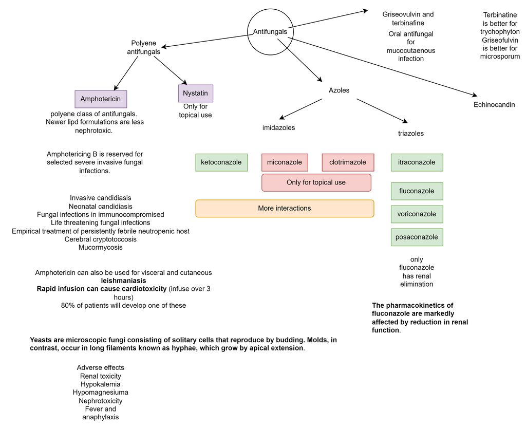

| Tuberculoid | Lepromatous leprosy |
| --- | --- |
| Not infectious | Infectious |
| Few, well described lesions | Widely distributed lesions, poorly defined border |
| Asymmetric distribution | Symmetric distribution |
| Hypopigmented lesions | Slight hypopigmentation or erythema |
| Dry (anhydrous) scaly appearance | Smooth, shiny surface |
| hairless, anaesthetic | **Late impariment of sweating or sensation** |
| Marked, early never damage | Nerve damage is slow but progressive |
| Single, local nerve enlargement | No nerve enlargement |
| Single nerve involvement | Glove and stocking distribution of neuroopathy |
| (commonest: ulnar, posterior tibial, common peroneal) | Distal weakness of intrinsic muscles of hands and feet. |
| **Histology**: |  |
| Granulomas Present | No granulomas |
| Epitheliloid cells Present | Epitheliloid cells absent. |
| Type 1 | Type 2 |
| :-------------------------------------------------------------------: | :----------------------------------------------------------------------: |
| Type 4 HS reaction | Type 3 HS reaction |
| Erythema of previous lesions | abrupt onset Subcutaneous painful nodules + constitutional symptoms |
| No systemic symtpoms | Systemic symptoms occur. Lymphadenopathy and other organ involvement. |
| CRP and WBC normal | CRP and WBC elevated |
| Clinical diagnosis | Biopsy required; shows polymorphs. |
| Severe Neuritis -> Foot drop | Neuritis may be present. |
| Occurs in borderline disease | Occurs in **lepromatous** and **borderline** lepromatous leprosy |
| Thalidomide *is ineffective*; clorazimine has 'questionnable benefit' | Clofazimine prevents type II reactions. Thalidomide can be used. |
| Occurs in Borderline disease (BT to BL) | Occurs in BL or LL disease |
| managed with corticosteroid | First line is corticosteroids |
| Both share symptoms of **neuritis, arthritis, iritis and nasopharyngeal symptoms**. |  |
| Can lead to **severe nerve injury with subsequence paralysis and deformity**. |  |
| Type 1: (aka T1R, RR - '*reversal* reaction') |  |

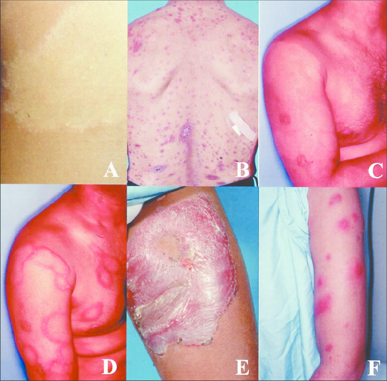

  Clinical signs associated with leprosy in various stages of the disease. A: Large hypopigmented macule of TT leprosy. B: BL leprosy. C: BB leprosy before therapy. D: The same patient as in Fig. 2C undergoing a type I reversal reaction during therapy. Note the accentuation and erythema of macules relative to Fig. 2C. E: Patient with BT leprosy undergoing a type I reversal reaction. F: Patient with LL leprosy undergoing a type II reaction (erythema nodosum leprosum). Note the raised, erythematous crops of nodules. [Source](https://www.researchgate.net/figure/Clinical-signs-associated-with-leprosy-in-various-stages-of-the-disease-A-Large_fig2_8933233)  
  **Clofazimine** causes a copper (red and dark skin and hair) pigmentation, particularly on *areas exposed to light* starting during the first 10 weeks of treatment. This is **reversible** but takes several months. Also causes *icthyosis*.

> [!INFO] Overview of thrombophilia  
> Predisposition to thrombosis:
> - Heritable thrombophilias, acquired thrombophilias, Haemolytic anaemias (+?others)  
>   **Heritable** thrombophilias
> 1. Factor V Leiden - gain of coagulant function
> 2. Protein C deficiency - loss of anticoagulant function
> 3. protein S deficiency - loss of anticoagulant function
> 4. Antithrombin deficiency

> **Acquired** thrombophilias
> 1. Antiphospholipid syndrome is an **acquired** thrombophilia.

> **Haemolytic anaemias** can *predispose to thrombosis*, particularly
> 1. [[Cytopaenias#Paroxysmal nocturnal haemoglobinuria|PNH]]
> 2. Thalassemia
> 3. Sickle cell anaemia
> 4. Haemolysis in general.
> 5. There can be mulitple mechanisms [Source](https://ashpublications.org/hematology/article/2007/1/74/19183/Coagulation-in-the-Pathophysiology-of-Hemolytic)

```
- 30-50% of SLE patients have antiphopholipid  antibodies.
```

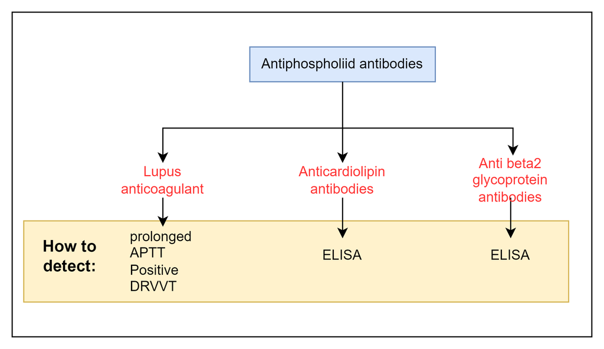

- These antibodies bind to their corresponding plasma proteins when the proteins bind to membrane phospholipids (?which probably induces a conformational change) [Source](https://emedicine.medscape.com/article/2116457-overview)

> ***Don't read this bit**: It's Confusing ;)

> > However, aPL is also directed against a variety of other antigenic targets such as prothrombin (PT), phosphatidylserine/prothrombin (PS/PT) complexes, vimentin/cardiolipin complexes, annexin A2, *lupus anticoagulant* and annexin A5  
> > They appear to have anticoagulant activity because they **prolong APTT**.
- **DRVVT** test - very sensitive to lupus anticoagulant effect.

```
1.see [[#Cryptosporidiosis]] below
```

### Cryptosporidiosis

[figure not shown]

In **patients with HIV, the most common cause of infective diarrhoea** is cryptosporidiosis,  
1. Transmitted by drinking infected water -> watery diarrhoea, lasting 1 - 2 weeks. **infective dose is < 100 oocytst**  
2. "don't go swimming with diarrhoea"  
3.

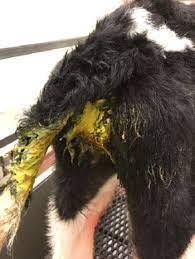

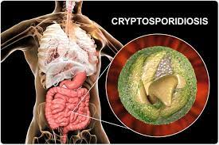

4. They infest the epithelial cells of the intestine (**intracellular parasites**). They produce **thick** (infective) and **thin** cysts (autoinfection). **Oocysts are resistant to chlorine levels found in pools**.  
5. **Diagnosis** - oocysts in stool but *routine stool examination isn't sensitive enough*. **Acid fast stains** and concentration techniques are required to increase sensitivity. (?hence the name crypto)  
6. In both *immunocompetent and immunocompromised patients*, *for non-severe acute symptoms*, **supportive therapy is the mainstay** of treatment.  
7. For chronic refractory cryptosporidiosis, especially immunocompromised patients, **nitazoxanide** may be used  
8. They're using 'organoids' to develop treatment. Source

- Endospores can survive alcohol and temperatures upto 150C.
- Adequate water and optimum temperature.

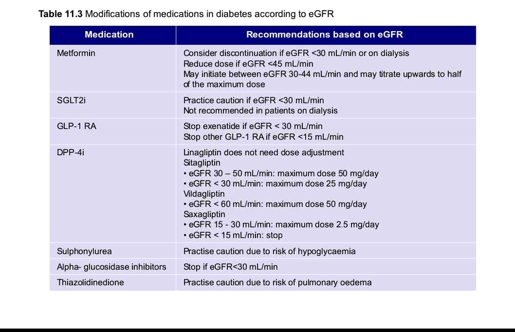

- Normally, the LOS remains closed between swallows because of intrinsic properties of it's muscles.
- Transient lower oesophageal sphincter relaxations occur during swallowing (TLESRs) to allow food to pass.
- The frequency of TLESRs increases in patients with GORD allowing gastric contents to reflux.
- Any residual reflux is cleared by *secondary peristalsis, salivary bicarbonate, and gravity*.  
  An "Acid pocket" of acid not neutralized by incoming food and fluid can serve as a reservoir of 'refluxable' acid. This can be targeted with an *antacid-alginate* combination.
- Treatment is initiated on clinical diagnosis.

However, *Endcoscopy is indicated in*

- *refractory* cases or
- those with *red flag symptoms* (dysphagia, weight loss, bleeding) or
- for patients with longstanding reflux (*≥10 years*) as they have a high risk of [[2020-NOV-BasicSciences#Barrett oesophagus|Barrett's Oesophagus]]
- **Demonstration of oesophagitis or Barrett's oesophagus on endoscopy confirms GORD.**

> "Upper endoscopy is **not required to make a diagnosis of GERD**. However, upper endoscopy can detect esophageal manifestations of GERD (eg, Barrett’s metaplasia, erosive esophagitis) and can rule out an upper gastrointestinal tract malignancy"

Endoscopy is *sensitive for **oesophagitis*** but it will *miss* **nonerosive** reflux disease. (*NERD*)

- Symptoms are 'often' *functional* or due to hypersensitive oesophagus.
- The **most sensitive test** -> **24 ambulatory pH monitoring**. (used to assess the cause when symptoms are refractory)
- **Oesophgeal manometry** is done to exclude motility disorder in patients with chest pain and *normal upper GI endoscopy*  
  The **DeMeester score** is a composite of *pH* and *manometry* (?and other) and if ≥ 14.72, indicates presence of reflux.
1. *Alginate containing antacids* - 10ml tds - most common treatment. Forms a gel raft which prevents reflux.
2. *PPIs* - 4 weeks course of once daily PPI resolves symptoms in 60%.
   1. The role of prokinetics is limited due to lack of data [Source](https://www.ncbi.nlm.nih.gov/books/NBK441938/)
   2. Domperidone, cisapride, mosapride (cisapride and mosapride can cause arrhythmias)
3. invasive

> Type 1: "more cysts, more frequent, more chromosomes", Type 1 and '16' both have the digit 1.

> [!INFO] **Key point**: *ADH* may promote cyst growth.
- Manage **blood pressure** with *ACEi / ARB*

# Neurocysticercosis

> - Mnemonic: Beef tape worm eggs **will not 'germinate' in human intestine**

# Taeniasis

[figure not shown]

# Echinococcosis

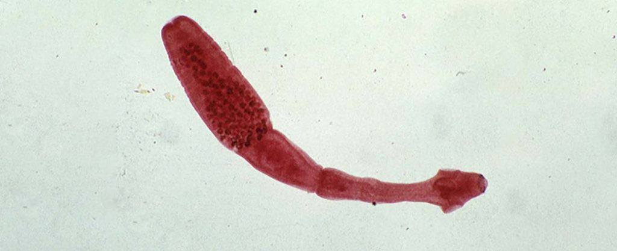

Dog *tape worm*

- A *2-7mm long small tape worm* whose **definitive host is the dog**.
  - Intermediate host is animals like sheep.
- Sheep tissues have cysts which are infective when **ingested** by a dog.
- The adult forms in the dog then shed **eggs** **with faeces** which are usually ingested by the sheep, but can also be ingested by humans.
- One ingested, the eggs hatch the the larvae penetrate the intestinal wall and take up **residence in the tissues**.
- In the tissues, they from **hydatid cysts**.
- The cysts usually grow for many years and are asymptomatic until they cause symptoms due to pressure effects.
  - Watch and wait stragegy can be used.
- However, if a cyst ruptures, it can cause analphylaxis, or a milder fever, and dissemination of the parasites within.
- Humans acquire the infections as **accidental intermediate hosts** by ingesting food contaminated with definite host's faeces.
  - Humans cannot get hydatid diseas from eating undercooked meat. [Source](https://britishlivertrust.org.uk/information-and-support/liver-conditions/hydatid-cysts/)
- **Treatment:** **Surgery** or less invasive procedures like *PAIR* (percutaneous aspiration, injection of chemicals and reaspiration).

Causes of anaemia in SLE:

1. Anaemia of chornic disease (ACD)
2. AIHA
3. MAHA
4. Pernicious anaemia
5. Iron deficiency anaemia
6. Medications
7. Pure red cell aplassia

( Therefore, dominance refers to which artery supplies the AV node. Not the SA node )

## Blood supply of the conducting system

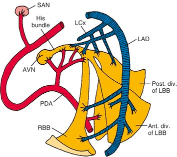

[Source](https://thoracickey.com/pacing-for-atrioventricular-conduction-system-disease/)

- The proximal *portion of the RBB* is supplied by branches *from the AV nodal artery* or *the LAD artery*, whereas the **more distal portion** is supplied mainly by **branches of the LAD artery**
- The LBB and its **anterior fascicle** have a blood supply *similar to that of the proximal portion of the RBB*;
- the **left posterior** fascicle is supplied by branches of the **AV nodal artery**, the **posterior descending artery**, and the **circumflex coronary artery**.  
  Left coronary sinus is also called "left posterior sinus".  
  Non coronary sinus is also called "right posterior sinus"
- (search) - Obtuse marginal artery